# hw1_Kenny

Christopher Kenny

February 23, 2018

## Set-Up:

```r
library(tidyverse, warn.conflicts = F, quietly = T, verbose = F)
```

## Section 1: Initial Set Up:

· Load the Democracy dataset into memory as a dataframe. Use the read.csv function, and the stringsAsFactors = FALSE option. Note that missing values are indicated by “.” in the data. Find the option in read.csv that controls the string used to indicate missing values.

```r
democracy <- read.csv(file = 'democracy.csv', stringsAsFactors = F, na.strings = '.')
```

## Section 2: Initial Data Exploration:

· Report summary statistics (means and medians, at least) for all variables.

```r
summary(democracy)
```

```
##     COUNTRY         CTYNAME             REGION               YEAR
##  Min.   :  1.00   Length:4126        Length:4126        Min.   :1951
##  1st Qu.: 39.00   Class :character   Class :character   1st Qu.:1965
##  Median : 71.00   Mode  :character   Mode  :character   Median :1974
##  Mean   : 70.18                                         Mean   :1973
##  3rd Qu.:103.00                                         3rd Qu.:1983
##  Max.   :135.00                                         Max.   :1990
##
##     BRITCOL            CATH           CIVLIB           EDT
##  Min.   :0.0000   Min.   : 0.00   Min.   :1.000   Min.   : 0.030
##  1st Qu.:0.0000   1st Qu.: 0.00   1st Qu.:2.000   1st Qu.: 2.214
##  Median :0.0000   Median :22.25   Median :5.000   Median : 4.540
##  Mean   :0.2433   Mean   :37.20   Mean   :4.076   Mean   : 4.853
##  3rd Qu.:0.0000   3rd Qu.:84.00   3rd Qu.:6.000   3rd Qu.: 7.085
##  Max.   :1.0000   Max.   :99.00   Max.   :7.000   Max.   :12.810
##                                   NA's   :1727    NA's   :1226
##      ELF60             GDPW           MOSLEM           NEWC
##  Min.   :0.0000   Min.   :  480   Min.   : 0.00   Min.   :0.0000
##  1st Qu.:0.1000   1st Qu.: 2458   1st Qu.: 0.00   1st Qu.:0.0000
##  Median :0.3700   Median : 6012   Median : 0.50   Median :0.0000
##  Mean   :0.3995   Mean   : 8877   Mean   :19.74   Mean   :0.4561
##  3rd Qu.:0.6900   3rd Qu.:12608   3rd Qu.:16.20   3rd Qu.:1.0000
##  Max.   :0.9300   Max.   :37903   Max.   :99.90   Max.   :1.0000
##  NA's   :542
##       OIL             POLLIB          REG              STRA
##  Min.   :0.0000   Min.   :1.00   Min.   :0.0000   Min.   :0.0000
##  1st Qu.:0.0000   1st Qu.:2.00   1st Qu.:0.0000   1st Qu.:0.0000
##  Median :0.0000   Median :3.00   Median :0.0000   Median :0.0000
##  Mean   :0.1001   Mean   :3.86   Mean   :0.3987   Mean   :0.3752
##  3rd Qu.:0.0000   3rd Qu.:6.00   3rd Qu.:1.0000   3rd Qu.:1.0000
##  Max.   :1.0000   Max.   :7.00   Max.   :1.0000   Max.   :5.0000
##                   NA's   :1727
```

We see here that the summary command will allow us to easily get basic summary statistics, but we must note that it also shows some weird (and expected) default typing, as variables like OIL or REG have been coerced to a numerical (or integer) type instead of a boolean type.

· Create a histogram for political liberties in which each unique value of the variable is in its own bin.

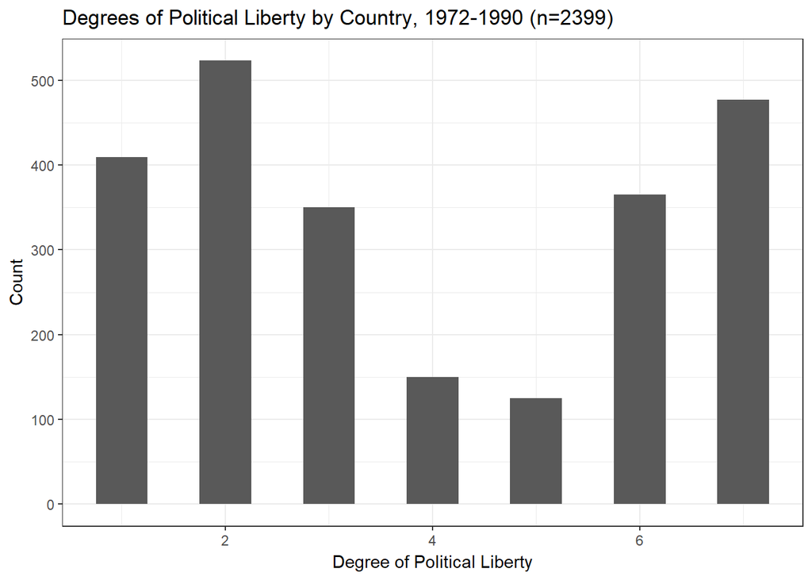

```r
democracy %>% ggplot(aes(x = POLLIB)) +
  geom_histogram(stat="bin", binwidth = .5, na.rm = T) +
  labs(x='Degree of Political Liberty', y= 'Count', title='Degrees of Political Liberty by Country, 1972-1990 (n=2399)') +
  theme_bw()
```

Here, we use a binwidth of 0.5 to separate the integer values for Degree of Political Liberty. This shows us that the most common government types are close to a democracy at a 6 or 7 or far away at a 1 or 2. Yet, this bar graph choice is unclear, as it uses every year without a way to distinguish countries. It would be better to slice this by year, or use fewer years with color indicating the year.

· Create a histogram for GDP per capita.

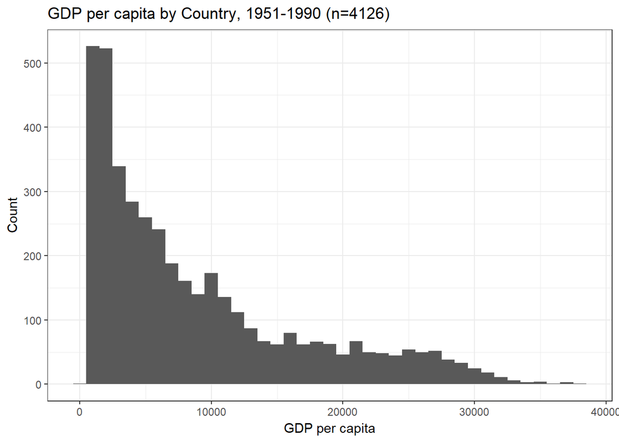

```r
democracy %>% ggplot(aes(x=GDPW)) +
  geom_histogram(stat='bin',binwidth = 1000) +
  labs(x = 'GDP per capita',y = 'Count', title = 'GDP per capita by Country, 1951-1990 (n=4126)') +
  theme_bw()
```

This illustrates that most countries fall on the lower end of the GDP per capita scale, but has similar issues as the previous graph, as the differences in countries are accounted for multiple times, leading to more drastic differences in the counts for each bar. Again, it would be better to slice this for a single year. This graph would be a very good choice to use gganimate to make a moving graph with the year as the frame.

· Create a histogram for log GDP per-capita. How is this histogram different than the one for GDP per capita when it was not logged.

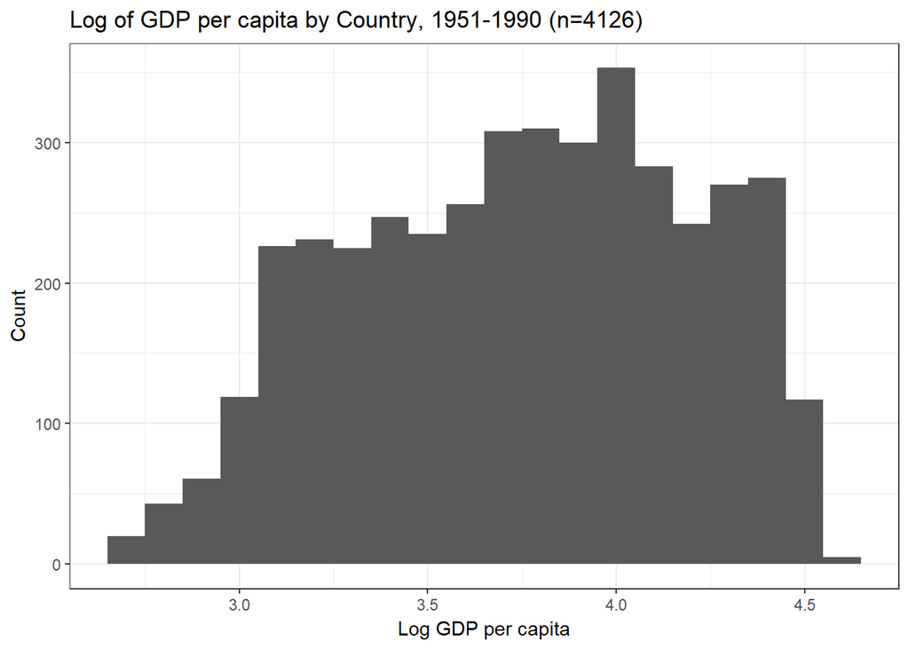

```r
democracy %>% ggplot(aes(x=log10(GDPW))) +
  geom_histogram(stat='bin', binwidth = .1) +
  labs(x = 'Log GDP per capita',y = 'Count', title = 'Log of GDP per capita by Country, 1951-1990 (n=4126)') +
  theme_bw()
```

This graph is different because it represents the data by powers of 10, into bins of .1. This may look cleaner because the bulk of the data now sits near the center of the graph, however, it could be argued that this is more misleading because the difference between 3.0 and 4.0 now looks very small but it is the difference between 1,000 and 10,000, which is actually a very significant difference. The original inequality in GDP per capita that exists before transforming the data is not nearly as visible. Despite this, they technically both accurately depict the same 4126 pieces of data, just the clarity of exposition has changed.

## Section 3: Explore Relationships:

· Create a scatterplot of political liberties against GDP per capita.

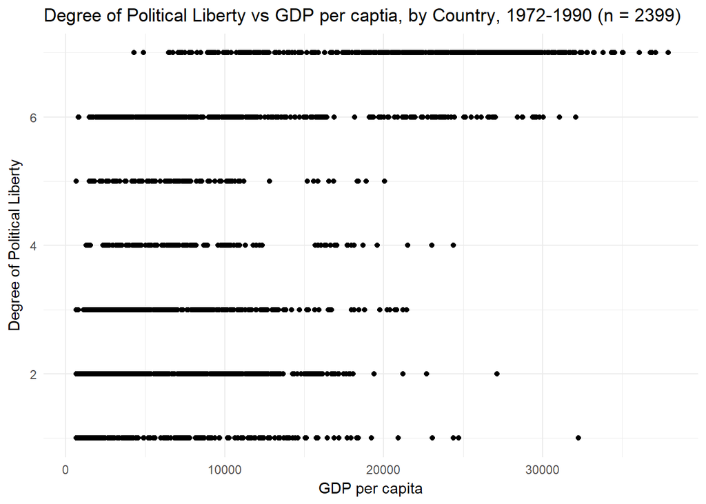

```r
democracy %>% ggplot(aes(y=POLLIB,x=GDPW)) +
  geom_point(na.rm = T) +
  theme_minimal() +
  labs(x = 'GDP per capita', y = 'Degree of Political Liberty',
       title = 'Degree of Political Liberty vs GDP per captia, by Country, 1972-1990 (n = 2399)')
```

We see here that, in general, a weak relationship that as GDP per capita increases, the Degree of Political Liberty increases. It can be a bit difficult to see this, as there are so many points that they blend together.

· When there is a lot of overlap in a scatter plot it is useful to “jitter” the points (randomly move them up and down). Make the previous plot but jitter the points to mitigate the problem of overplotting. (Only jitter the points vertically). You can use geom_jitter in ggplot2 for this.

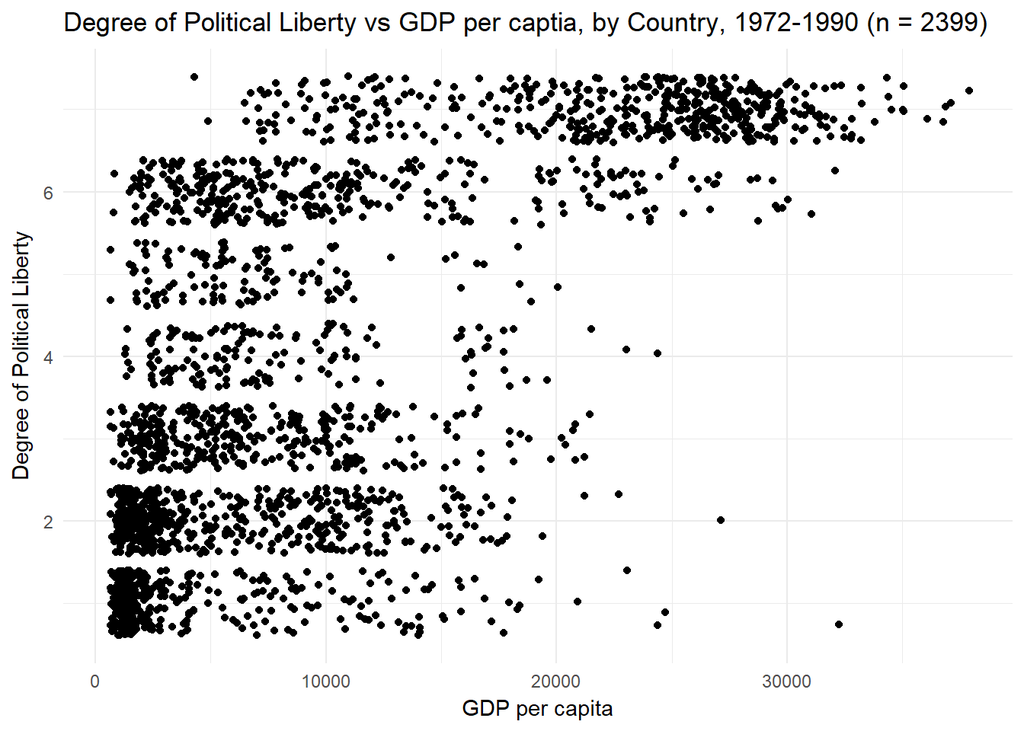

```r
democracy %>% ggplot(aes(y=POLLIB,x=GDPW)) +
  geom_jitter(na.rm = T) +
  theme_minimal() +
  labs(x = 'GDP per capita', y = 'Degree of Political Liberty',
       title = 'Degree of Political Liberty vs GDP per captia, by Country, 1972-1990 (n = 2399)')
```

Here, we see a better version of the previous graph, with the same weak direct relationship, but more exaggerated, as the direct relationship in the data is now more visible with the increased clarity in the density of points.

· Create a scatterplot of political liberties against log GDP per capita. Jitter the points. How is the relationship different than when GDP per capita was not logged.

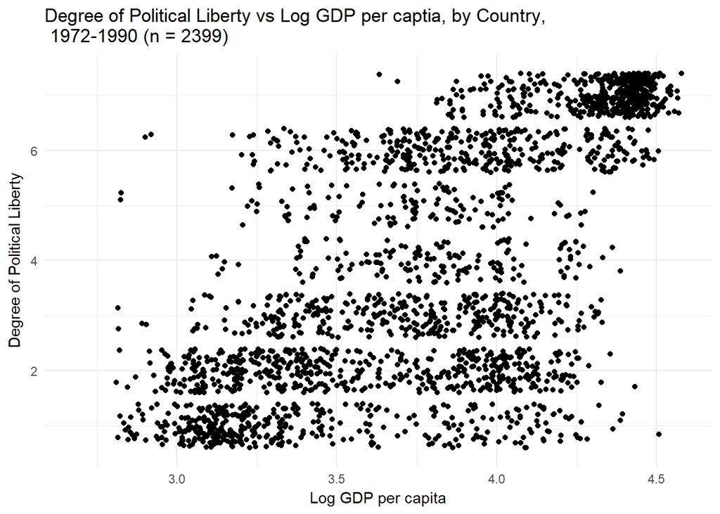

```r
democracy %>% ggplot(aes(y=POLLIB,x=log10(GDPW))) +
  geom_jitter(na.rm = T) +
  theme_minimal() +
  labs(x = 'Log GDP per capita', y = 'Degree of Political Liberty',
       title = 'Degree of Political Liberty vs Log GDP per captia, by Country,\n 1972-1990 (n = 2399)')
```

Now, we are able to see that the relationship is not quite so weak, and that it may be said that there is a strong relationship between the increase in the Log GDP per captia and the increase in Degree of Political Liberty. This strength in relationship is the primary difference between this graph and the previous.

As a caveat, we note however, that a jitter plot is not a typical choice to plot the relationship between a discrete and a continuous variable, though it does convey the message intended in this particular case.

· Create a boxplot of GDP per capita for oil producing and non-oil producing nations.

```r
democracy$OIL <- as.logical(democracy$OIL)
```

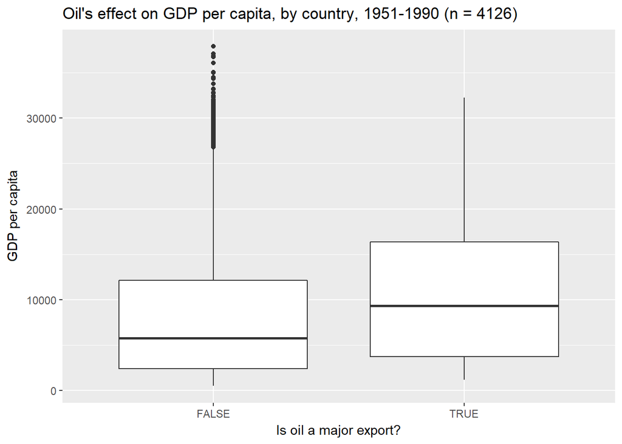

```r
democracy %>% ggplot(aes(x = OIL, y= GDPW)) +
  geom_boxplot() +
  theme_grey() +
  labs(x = 'Is oil a major export?', y =  'GDP per capita',
       title = 'Oil\'s effect on GDP per capita, by country, 1951-1990 (n = 4126)')
```

After fixing the type of OIL, we are able to see that countries with oil money tend to have a higher GDP per capita, but that there are a fair number of outliers who have higher GDP but are not major oil exporters. This is expected, but the number of countries represented as outliers is overrepresented, as there are 40 years of data in this one graph, so rich countries without oil would very likely be represented near 40 times if they are represented as an outlier at all.

## Section 4: Transform Data and Analyze:

· Calculate the mean GDP per capita in countries with at least 40 percent Catholics. How does it compare to mean GDP per capita for all countries?

```r
democracy %>% filter(CATH >= .4) %>% summarize(meanCath = mean(GDPW))
```

```
##   meanCath
## 1 10067.55
```

```r
democracy %>% summarize(mean = mean(GDPW))
```

```
##       mean
## 1 8876.959
```

· Calculate the average GDP per capita in countries with greater than 60% ethnolinguistic fractionalization, less than 60%, and missing ethnolinguistic fractionalization. Hint: you can calculate this with the dplyr verbs: filter,mutate, group_by and/or summarise. Like everything else there are multiple ways to do this; some more simple (require only one or two verbs) other more complex where you might need to combine multiple verbs and perhaps might need to do some googling.

```r
democracy %>% filter(ELF60 > .60) %>% summarize(meang60 = mean(GDPW))
```

```
##    meang60
## 1 3590.939
```

```r
democracy %>% filter(ELF60 < .60) %>% summarize(meanl60 = mean(GDPW))
```

```
##    meanl60
## 1 11803.78
```

```r
democracy %>% filter(is.na(ELF60)) %>% summarize(meanNA = mean(GDPW))
```

```
##     meanNA
## 1 7767.245
```

In countries with more than 60% ethnolinguistic fractionalization, the mean GDP per capita is $3,590.94. In countries with less than 60% ethnolinguistic fractionalization, the mean GDP per capita is $11,803,78. In countries with unavailable ethnolinguistic fractionalization, the mean GDP per capita is $7,767.25. The first relationship is as expected, that less fractionalization would occur in relatively richer countries. The NA output is roughly the mean of the other two, but this would require further investigation as to why the values are NA to understand what the relationship is.

· What was the median of the average years of education in 1985 for all countries?

```r
democracy %>% filter(YEAR == 1985) %>% summarize(med = median(EDT, na.rm = T))
```

```
##     med
## 1 5.625
```

The median of the average years of education in 1985 for all countries was 5.625 years.

· Which country was (or countries were) closest to the median years of education in 1985 among all countries?

```r
democracy %>% filter(YEAR == 1985) %>% filter(EDT == 5.625)
```

```
##   COUNTRY   CTYNAME        REGION YEAR BRITCOL CATH CIVLIB   EDT ELF60
## 1      77 Venezuela South America 1985       0   95      2 5.625  0.11
##    GDPW MOSLEM NEWC  OIL POLLIB REG STRA
## 1 18362      0    0 TRUE      7   1    1
```

Venezuela had the median years of education in 1985 among all countries.

· What was the median of the average years of education in 1985 for democracies?

```r
democracy$REG <- as.logical(democracy$REG)
```

First, we fix the type.

```r
democracy %>% filter(YEAR == 1985 & REG == T) %>% summarize(med = median(EDT, na.rm = T))
```

```
##     med
## 1 7.805
```

Now, we are able to see that among democracies in 1985, the median number of years of education was 7.805 years.

· Which democracy was (or democracies were) closest to the median years of education in 1985 among all democracies?

```r
democracy %>% filter(YEAR == 1985 & REG == T) %>% filter(EDT == 7.805)
```

```
##   COUNTRY   CTYNAME REGION YEAR BRITCOL CATH CIVLIB   EDT ELF60 GDPW
## 1      29 Mauritius Africa 1985       1 25.7      2 7.805  0.58 7474
##   MOSLEM NEWC   OIL POLLIB  REG STRA
## 1   12.9    1 FALSE      6 TRUE    0
```

Mauritius had the median years of education amoung democracies in 1985.

· What were the 25th and 75th percentiles of ethnolinguistic fractionalization for new and old countries?

```r
democracy$NEWC <- as.logical(democracy$NEWC)
```

Again, we fix the type from what read.csv assumed as default.

```r
democracy %>% filter(NEWC == T) %>% select(ELF60) %>% quantile(probs = c(0.25,0.75), na.rm = T)
```

```
##  25%  75%
## 0.42 0.75
```

```r
democracy %>% filter(NEWC == F) %>% select(ELF60) %>% quantile(probs = c(0.25,0.75), na.rm = T)
```

```
##  25%  75%
## 0.06 0.44
```

Now, we see that among new countries, the 25th percentile was 0.42 ethnolinguistic fractionalization and the 75th percentile was 0.75 ethnolinguistic fractionalization. HOwever, in old countries the 25th percentile was 0.06 ethnolinguistic fractionalization and the ethnolinguistic fractionalization was 0.44. This helps confirm the assumption that older countries would have a more established culture.